# 30DayChartChallenge2024

Source Code for All Contributed Charts

Author

Joshua J. Cook, M.S., ACRP-PM, CCRC

Published

April 3, 2024

# Information

[figure not shown]

[Post | Feed | LinkedIn](https://www.linkedin.com/feed/update/urn:li:activity:7180675688549511168/)

[30DayChartChallenge/Edition2024 (github.com)](https://github.com/30DayChartChallenge/Edition2024)

# Data

```r
clinical_trials_fl <- readRDS("data/query_results_fl_clean_final.rds")
clinical_trials_fl_mesh <- readRDS("data/query_results_fl_clean_final_mesh.rds")
clinical_trials_fl_mesh_neo_joined <- readRDS("data/clinical_trials_fl_mesh_neo_joined.rds")
```

# Comparisons

### 1. Part-to-whole

Part-to-whole charts display individual pieces or segments of data that make up a whole. Common examples are pie charts and stacked bar charts. These visualizations aid in understanding proportions or percentages that contribute to the whole (which is the case in this **treemap** example). For today’s example, we will visualize the proportion of conditions (using MeSH terms) that have been studied over the past 10 years in Florida. This visualization was inspired by the treemapping work of [Yobanny Sámano](https://twitter.com/ysamano28): [Treemap with annotations, labels and colors – the R Graph Gallery (r-graph-gallery.com)](https://r-graph-gallery.com/web-treemap-with-annotations-labels-and-colors.html).

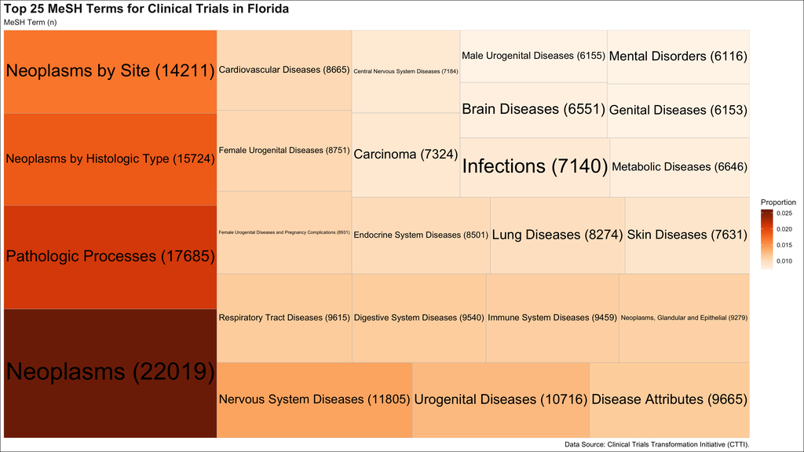

```r
packages <- c("tidyverse", "treemapify", "RColorBrewer")

if (any(!sapply(packages, requireNamespace, quietly = TRUE))) {
  install.packages(packages[!sapply(packages, requireNamespace, quietly = TRUE)])
}

library(tidyverse)
library(treemapify)
library(RColorBrewer)

#str(clinical_trials_fl)

# Step 1: Calculate frequencies for each mesh_term
clinical_trials_freq <- clinical_trials_fl_mesh %>%
  filter(!is.na(mesh_term)) %>%
  count(mesh_term) %>%
  mutate(total = sum(n), Proportion = n / total) %>%
  ungroup()

# Step 2: Select the top 30 mesh_terms based on frequency
top_25_mesh_terms <- clinical_trials_freq %>%
  arrange(desc(n)) %>%
  top_n(25, n) %>%
  mutate(label = paste(mesh_term, " (", n, ")", sep = "")) # Creating a new column 'label' for treemap labels

# Step 3: Generate the treemap - ggplot2 style
# Get colors from the "Oranges" palette
# You can adjust the number of colors based on your data
colors <- brewer.pal(9, "Oranges")

ggplot(top_25_mesh_terms, aes(area = n, fill = Proportion, label = label)) +
  geom_treemap() +
  geom_treemap_text(colour = "black", place = "centre", grow = TRUE) +
  scale_fill_gradientn(colours = colors) + # Using "Oranges" palette
  labs(
    title = "Top 25 MeSH Terms for Clinical Trials in Florida",
    subtitle = "MeSH Term (n)",
    caption = "Data Source: Clinical Trials Transformation Initiative (CTTI)."
  ) +
  theme_minimal() +
  theme(plot.background = element_rect(fill = "white"),
        text = element_text(color = "#1E1D23"),
        plot.title = element_text(size = 18, face = "bold"),
        plot.caption = element_text(size = 10, color = "black"))
```

```r
ggsave("chart_1.png", width = 16, height = 9, dpi = 300)
```

### 2. Neo

Interestingly, yesterday’s analysis revealed that the most frequent MeSH term studied in Florida was **neoplasms**. Let’s see how many patients in Florida are receiving neoplasm treatment through clinical research studies. Importantly, a distinction should be made between **interventional** studies (i.e., those with a drug, device, or other treatment being administered), and **observational** studies (no treatment administered).

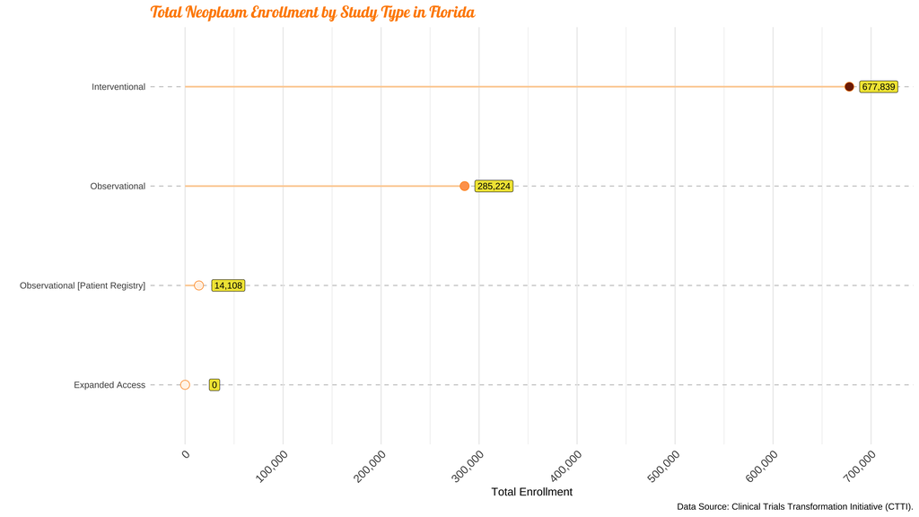

```r
packages <- c("tidyverse", "RColorBrewer", "showtext")

if (any(!sapply(packages, requireNamespace, quietly = TRUE))) {
  install.packages(packages[!sapply(packages, requireNamespace, quietly = TRUE)])
}

library(tidyverse)
library(RColorBrewer)
library(showtext)

# A Florida-esque font from Google
font_add_google("Lobster", "lobster")
showtext_auto()

# Filter for the top MeSH term
clinical_trials_fl_mesh_neo <- clinical_trials_fl_mesh %>%
  filter(mesh_term == "Neoplasms") %>%
  group_by(mesh_term) %>%
  distinct(nct_id)

# Retrieve original features
clinical_trials_fl_distinct <- clinical_trials_fl %>%
  select(c(1, 4, 9, 10, 11, 12, 13, 16, 17, 18, 38, 39)) %>%
  distinct()

# Join the dataframes on nct_id
clinical_trials_fl_mesh_neo_joined <- clinical_trials_fl_distinct %>%
  inner_join(clinical_trials_fl_mesh_neo, by = "nct_id")

# Clean enrollment data
clinical_trials_fl_mesh_neo_joined <- clinical_trials_fl_mesh_neo_joined %>%
  mutate(
    enrollment_actual = if_else(enrollment_type == "Actual", enrollment, NA_integer_),
    enrollment_anticipated = if_else(enrollment_type == "Anticipated", enrollment, NA_integer_)
  )

# Clean study status
clinical_trials_fl_mesh_neo_joined <- clinical_trials_fl_mesh_neo_joined %>%
  mutate(overall_status = case_when(
    overall_status %in% c("Completed", "Approved for marketing") ~ "Completed",
    overall_status %in% c("Withdrawn", "Terminated", "Suspended", "No longer available") ~ "Not Completed",
    # Assuming any other status as "In Progress"
    TRUE ~ "In Progress"
  ))

clinical_trials_fl_mesh_neo_joined <- clinical_trials_fl_mesh_neo_joined %>%
  select(-c(enrollment, enrollment_type, enrollment_anticipated))

# Summarize total enrollment_actual by study_type
enrollment_by_study_type <- clinical_trials_fl_mesh_neo_joined %>%
  group_by(study_type) %>%
  summarise(total_enrollment = sum(enrollment_actual, na.rm = TRUE)) %>%
  ungroup() %>%
  arrange(desc(total_enrollment))

# Retrieve the Oranges palette
oranges_palette <- brewer.pal(n = 9, name = "Oranges")

# Lollipop chart with Oranges palette
p <- ggplot(enrollment_by_study_type, aes(x = reorder(study_type, total_enrollment), y = total_enrollment)) +
  geom_segment(aes(xend = study_type, yend = 0), color = oranges_palette[3], size = 1) + # Stems with a specific orange shade
  geom_point(aes(fill = total_enrollment), size = 5, color = "darkorange", shape = 21) + # Dots at the end of stems
  coord_flip() + # Flip coordinates to make it horizontal
  scale_y_continuous(labels = scales::comma, breaks = scales::pretty_breaks(n = 10)) +
  scale_fill_gradientn(colours = oranges_palette) + # Gradient fill for dots
  labs(title = "Total Neoplasm Enrollment by Study Type in Florida",
       x = "",
       y = "Total Enrollment",
       caption = "Data Source: Clinical Trials Transformation Initiative (CTTI).") +
  theme_minimal(base_size = 14) +
  theme(panel.grid.major.y = element_line(color = "gray80", linetype = "dashed"),
        panel.grid.minor.y = element_blank(),
        plot.title = element_text(family = "lobster", face = "bold", size = 20, color = "darkorange"),
        axis.title.y = element_text(size = 16, face = "bold"),
        axis.text.x = element_text(angle = 45, hjust = 1, size = 14),
        legend.position = "none") +
  geom_label(aes(label = scales::comma(total_enrollment)), nudge_y = 30000, size = 4, label.padding = unit(0.25, "lines"),
             color = "black", fill = "#F0E442") # Adding labels to the points for direct readability

p
```

```r
# Adjusting the plot with much larger text sizes for better readability when saving
p_adjusted_for_print <- p +
  theme(plot.background = element_rect(fill = "white", color = NA),
        panel.background = element_rect(fill = "white", color = NA),
        text = element_text(size = 40), # Doubling base text size
        plot.title = element_text(family = "lobster", size = 95, face = "bold", color = "darkorange"), # Much larger title
        axis.title = element_text(size = 60), # Doubling axis titles for clarity
        axis.title.y = element_text(margin = margin(r = 40)), # Add right margin to y-axis title for better spacing
        axis.text.x = element_text(angle = 45, hjust = 1, size = 50), # Much larger x-axis text
        axis.text.y = element_text(size = 50), # Much larger y-axis text
        legend.title = element_text(size = 50), # Much larger legend title
        legend.text = element_text(size = 36), # Much larger legend text
        plot.margin = margin(40, 40, 40, 40)) + # Adjust plot margins for better framing
  geom_label(aes(label = scales::comma(total_enrollment)), nudge_y = 30000, size = 14, # Adjust label sizes
             label.padding = unit(0.5, "lines"), color = "black", fill = "#F0E442")

ggsave("chart_2.png", plot = p_adjusted_for_print, width = 16, height = 9, dpi = 300, bg = "white")
```